# Forecasting Project

```python
import numpy as np
import pandas as pd
from statsmodels.tsa.stattools import adfuller
import matplotlib.pyplot as plt
from statsmodels.tsa.arima_model import ARIMA
import statsmodels.api as sm
from statsmodels.tsa.arima_model import ARMAResults
```

Data Introduction: this data is downloaded from quandl website . Link: "https://www.quandl.com/data/BOE/XUDLERD-Spot-Exchange-Rate-Euro-Into-Us" . It shows the exchange rate of Euro into dollar. It was hard to find a data that did not contain seasonality.I worked on various data sets before setting my mind on working on this data.

```python
import pandas as pd
# filename = 'telco.csv'
# fullpath = path+'/'+filename
data = pd.read_csv("C:/Users/Farhat/Desktop/BOE-XUDLERD.csv ", delimiter=',',index_col=[0],parse_dates=[0], squeeze=True)
```

```python
data.head()
```

```
Date
2020-06-04    0.8814
2020-06-03    0.8914
2020-06-02    0.8942
2020-06-01    0.8979
2020-05-29    0.8990
Name: Value, dtype: float64
```

## Data Preprocessing and Visualization

```python
times_series= data.resample('W').mean()
```

- the W indicates that we want to resample by week.
- mean() is used to indicate that we want the mean speed during this period.
- Resampling my data by week to reduce its variability. The mean method will calculate the mean for each resampling method

```python
times_series.head()
```

```
Date
1975-01-05    0.76090
1975-01-12    0.75346
1975-01-19    0.75546
1975-01-26    0.74388
1975-02-02    0.73902
Freq: W-SUN, Name: Value, dtype: float64
```

```python
type(times_series)
```

```
pandas.core.series.Series
```

- As we can see the data type is already series

```python
times_series.isnull().sum()
```

```
0
```

- There are no missing values

```python
times_series.index
```

```
DatetimeIndex(['1975-01-05', '1975-01-12', '1975-01-19', '1975-01-26',
               '1975-02-02', '1975-02-09', '1975-02-16', '1975-02-23',
               '1975-03-02', '1975-03-09',
               ...
               '2020-04-05', '2020-04-12', '2020-04-19', '2020-04-26',
               '2020-05-03', '2020-05-10', '2020-05-17', '2020-05-24',
               '2020-05-31', '2020-06-07'],
              dtype='datetime64[ns]', name='Date', length=2371, freq='W-SUN')
```

- The time index is already a datetime type. " dtype= datetime64[ns]"

```python
times_series.describe()
```

```
count    2371.000000
mean        0.865555
std         0.149053
min         0.629540
25%         0.763970
50%         0.831800
75%         0.915612
max         1.521680
Name: Value, dtype: float64
```

We have 2371 observations of the exchange rates that oscillates between 0.6295 and 1.521

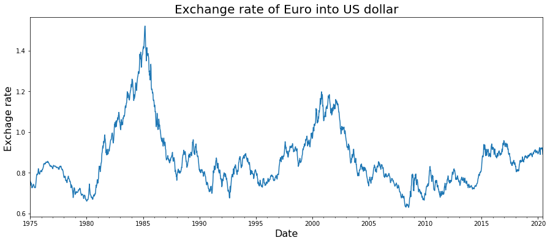

```python
times_series.plot(figsize=(15, 6))
plt.title('Exchange rate of Euro into US dollar', fontsize=20)
plt.ylabel('Exchage rate ', fontsize=16)
plt.xlabel('Date', fontsize=16)
```

### plots of the density of observations :

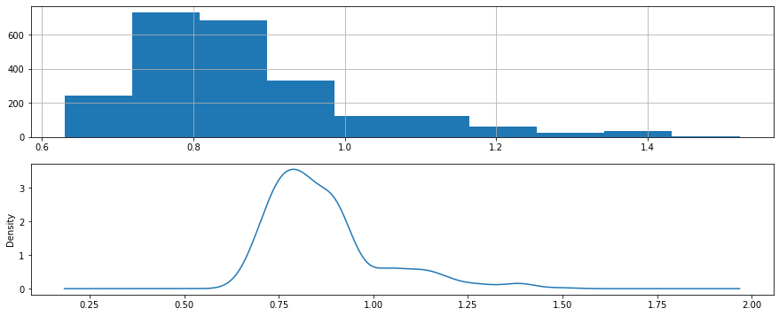

```python
from pandas import Series
from matplotlib import pyplot
pyplot.figure(1)
pyplot.subplot(211)
times_series.hist(figsize=(15, 6))
pyplot.subplot(212)
times_series.plot(kind='kde')
pyplot.show()
```

- The distribution is skewed to the right (Positive skew)
- The data is not perfectly distributed

```python
rollmean= times_series.rolling(window=20).mean()
rollstd= times_series.rolling(window=20).std()
```

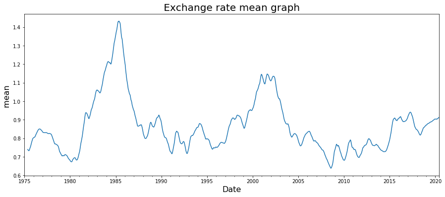

```python
rollmean.plot(figsize=(15, 6))
plt.title(' Exchange rate mean graph ', fontsize=20)
plt.ylabel('mean ', fontsize=16)
plt.xlabel('Date', fontsize=16)
```

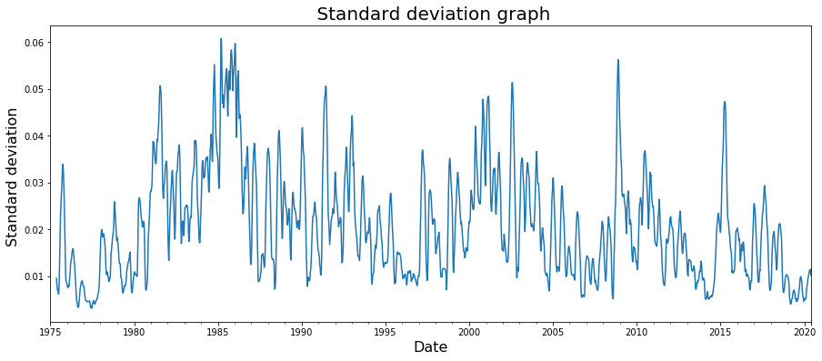

```python
rollstd.plot(figsize=(15, 6))
plt.title(' Standard deviation graph', fontsize=20)
plt.ylabel('Standard deviation ', fontsize=16)
plt.xlabel('Date', fontsize=16)
```

### Decomposing the data

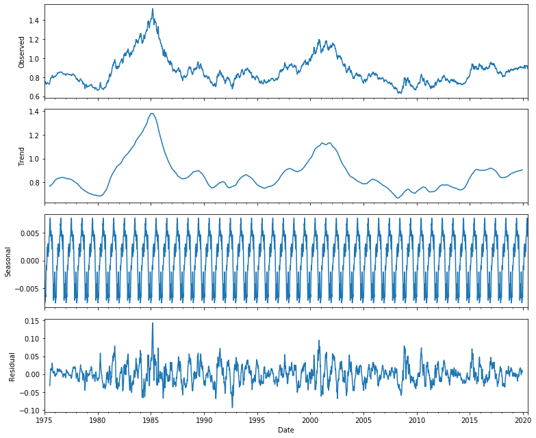

```python
from pylab import rcParams
import statsmodels.api as sm
rcParams['figure.figsize'] = 11, 9


decomposition = sm.tsa.seasonal_decompose(times_series, model='additive', freq=52)
fig = decomposition.plot()
plt.show()
```

- Thanks to the trend graph, we can see that the data is not constant over time which means that our process is probably not stationary

We will be dividing our data into test and train set

- **Train data: 80 percent**
- **Test set: 20 percent**

```python
size = int(len(times_series) * 0.8)
train, test = times_series[0:size], times_series[size:len(times_series)]
```

### stationarity

What is a stationarity process?

- A process is stationary if its statistical properties such as mean, variance remain constant over time.

Method

- To check the stationarity, we will be implementing the ADF (Augmented Dickey-Fuller) test.

```python
result = adfuller(train)
```

```python
print('ADF Statistic: %f' % result[0])
print('p-value: %f' % result[1])
print('Critical Values:')
for key, value in result[4].items():
	print('\t%s: %.3f' % (key, value))
```

```
ADF Statistic: -1.709684
p-value: 0.426130
Critical Values:
	1%: -3.434
	5%: -2.863
	10%: -2.568
```

- H0: the process is not stationary
- H1: the process is stationary

- So we need to work on the stationarity of our process.

We will start by checking the lambda value.

```python
from scipy.stats import boxcox
logged, lmd=boxcox(train)
print ("lambda parameter for Box-Cox Transformation is:",lmd)
```

```
lambda parameter for Box-Cox Transformation is: -2.1182313669093116
```

I could not generate the confidence inteval of lambda using python.So I used R and it had generated this output shown below.

The code that I used in R is :

- library(MASS)
- data = BOE_XUDLERD <- read_csv("BOE-XUDLERD.csv")
- g <- lm(Value ~ Date, data=data)
- boxcox(g, plotit = TRUE, lambda = seq(-4, 2, by = 0.1))

[figure not shown]

```python
from IPython.display import Image
Image(filename= "boxcox.png", width=1000)
```

INTERPRETATION:

- **0 ∉ to the confidence interval of lambda so I will not transform my data using log transformation**

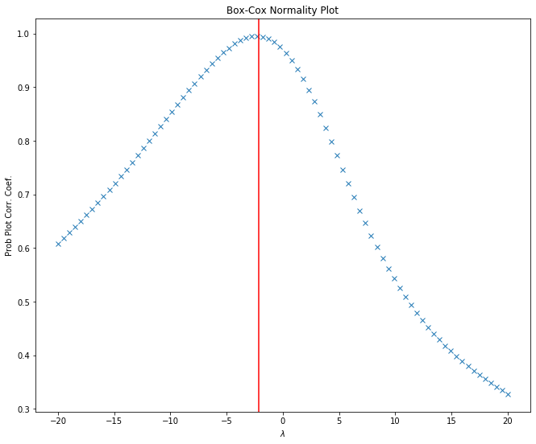

```python
from scipy.stats import boxcox_normplot
fig= plt.figure()
ax= fig.add_subplot(111)
prob= boxcox_normplot(train,-20,20,plot=ax)
_, maxlog=boxcox(times_series )
ax.axvline(maxlog, color='r')
plt.show()
```

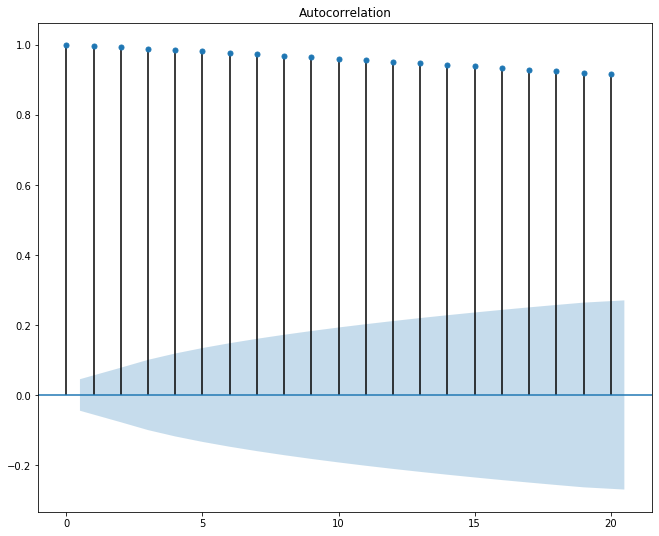

```python
from statsmodels.graphics.tsaplots import plot_acf
fig= plot_acf(train, lags=20)
```

- **The ACF decays very slowly so the process is not stationary**

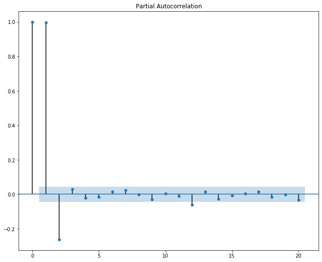

```python
from statsmodels.graphics.tsaplots import plot_pacf
fig= plot_pacf(train, lags=20)
```

### Differencing: To remove saisonality and trend

```python
#take the first difference
Data_diff=  train - train.shift(1)
```

```python
#set first difference as variable in data frame
Data_diff.dropna(inplace=True)
```

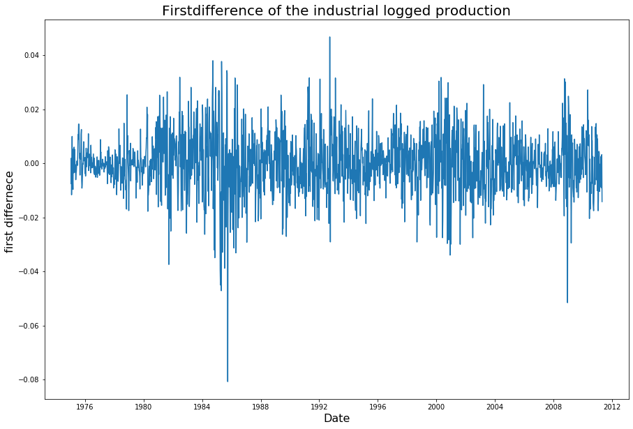

```python
plt.figure(figsize=(15,10))
plt.plot(Data_diff)
plt.title('Firstdifference of the industrial logged production', fontsize=20)
plt.ylabel('first differnece ', fontsize=16)
plt.xlabel('Date', fontsize=16)
```

#### the rolling mean and standard deviation

```python
rollmean= Data_diff.rolling(window=2).mean()
rollstd= Data_diff.rolling(window=2).std()
```

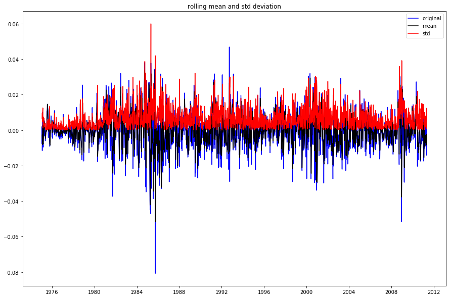

```python
plt.figure(figsize=(15,10))
orig= plt.plot(Data_diff,color='blue',label= 'original')
mean=plt.plot(rollmean,color='black',label= 'mean')
std=plt.plot(rollstd,color='red',label= 'std')
plt.legend(loc='best')
plt.title('rolling mean and std deviation')
plt.show(block=False)
```

- **As we can see the data is no longer increasing. The standard deviation (red graph ) and the mean (black graph) are constant with respect to time**
- **For the next step, I will be making the ADF test.**

```python
result2 = adfuller(Data_diff)
```

```python
print('ADF Statistic: %f' % result2[0])
print('p-value: %f' % result2[1])
print('Critical Values:')
for key, value in result2[4].items():
	print('\t%s: %.3f' % (key, value))
```

```
ADF Statistic: -27.392290
p-value: 0.000000
Critical Values:
	1%: -3.434
	5%: -2.863
	10%: -2.568
```

- **The p value (0) is less than 0.05 -> the process bacame stationary.**

### Identify p ,d, q: the parameters of ARIMA

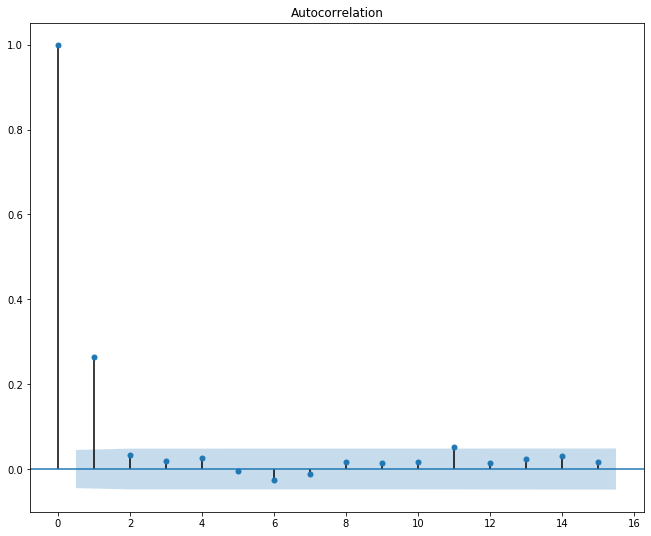

```python
from statsmodels.graphics.tsaplots import plot_acf
fig= plot_acf(Data_diff, lags=15)
```

- **The ACF have 1 spikes at lag 1=> q=1**

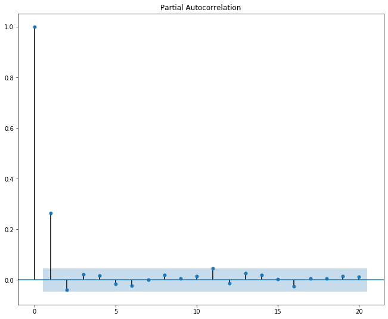

```python
from statsmodels.graphics.tsaplots import plot_pacf
fig= plot_pacf(Data_diff, lags=20)
```

- **The PACF have 1 spikes at lag 1 => p=1**
- **the difference is equal 1.**

The possible ARIMA models:

- ARIMA(1,1,1)
- ARIMA(1,1,0)
- ARIMA(0,1,1)

```python
!pip install pyramid.arima
```

```python
from pyramid.arima import auto_arima
stepwise_model = auto_arima(Data_diff, start_p=1, start_q=1,
max_p=3, max_q=3, m=12,
start_P=0, seasonal=True,
d=1, D=1, trace=True,
error_action='ignore',
suppress_warnings=True,
stepwise=True)
print(stepwise_model.aic())
```

[output not shown]

### Fitting the model

To fit our model, we used the 3 methods of estimation which are method of moments, maximum likelihood method, and least square estimation method

#### Method of moments

```python
from statsmodels.regression import linear_model
```

```python
rho, sigma = sm.regression.yule_walker(train, order=1)
print(f'rho coefficient: {-rho}')
print(f'sigma : {sigma}')
```

```
rho coefficient: [-0.99778073]
sigma : 0.010760883246323258
```

#### Maximum likelihood estimation method

#### AR Model

```python
modelARmle = ARIMA(train, order=(1,1,0))
modelAUTORmle= modelARmle.fit(model='mle')
print(modelAUTORmle.summary())
print('RSS: %.4f'% sum((modelAUTORmle.fittedvalues-Data_diff)**2))
print('sigma^2 is : %.4f'%modelAUTORmle.sigma2)
```

```
                             ARIMA Model Results
==============================================================================
Dep. Variable:                D.Value   No. Observations:                 1895
Model:                 ARIMA(1, 1, 0)   Log Likelihood                5956.659
Method:                       css-mle   S.D. of innovations              0.010
Date:                Fri, 19 Jun 2020   AIC                         -11907.318
Time:                        05:12:26   BIC                         -11890.678
Sample:                    01-12-1975   HQIC                        -11901.192
                         - 05-01-2011
=================================================================================
                    coef    std err          z      P>|z|      [0.025      0.975]
---------------------------------------------------------------------------------
const         -4.653e-05      0.000     -0.143      0.887      -0.001       0.001
ar.L1.D.Value     0.2649      0.022     11.957      0.000       0.221       0.308
                                    Roots
=============================================================================
                  Real          Imaginary           Modulus         Frequency
-----------------------------------------------------------------------------
AR.1            3.7747           +0.0000j            3.7747            0.0000
-----------------------------------------------------------------------------
RSS: 0.2065
sigma^2 is : 0.0001
```

#### MA Model

```python
modelMAmle = ARIMA(train, order=(0,1,1))
modelMovingAmle= modelMAmle.fit(model='mle')
print(modelMovingAmle.summary())
print('RSS: %.4f'% sum((modelMovingAmle.fittedvalues-Data_diff)**2))
print('sigma^2 is : %.4f'%modelMovingAmle.sigma2)
```

```
                             ARIMA Model Results
==============================================================================
Dep. Variable:                D.Value   No. Observations:                 1895
Model:                 ARIMA(0, 1, 1)   Log Likelihood                5957.348
Method:                       css-mle   S.D. of innovations              0.010
Date:                Fri, 19 Jun 2020   AIC                         -11908.696
Time:                        05:12:32   BIC                         -11892.055
Sample:                    01-12-1975   HQIC                        -11902.569
                         - 05-01-2011
=================================================================================
                    coef    std err          z      P>|z|      [0.025      0.975]
---------------------------------------------------------------------------------
const         -4.583e-05      0.000     -0.151      0.880      -0.001       0.001
ma.L1.D.Value     0.2679      0.021     12.471      0.000       0.226       0.310
                                    Roots
=============================================================================
                  Real          Imaginary           Modulus         Frequency
-----------------------------------------------------------------------------
MA.1           -3.7322           +0.0000j            3.7322            0.5000
-----------------------------------------------------------------------------
RSS: 0.2063
sigma^2 is : 0.0001
```

#### ARIMA Model

```python
modelmle2 = ARIMA(train, order=(1,1,1))
modelmle22= modelmle2.fit(model='mle')
print(modelmle22.summary())
print('RSS: %.4f'% sum((modelmle22.fittedvalues-Data_diff)**2))
print('sigma^2 is : %.4f'%modelmle22.sigma2)
```

```
                             ARIMA Model Results
==============================================================================
Dep. Variable:                D.Value   No. Observations:                 1895
Model:                 ARIMA(1, 1, 1)   Log Likelihood                5958.282
Method:                       css-mle   S.D. of innovations              0.010
Date:                Fri, 19 Jun 2020   AIC                         -11908.564
Time:                        05:12:41   BIC                         -11886.377
Sample:                    01-12-1975   HQIC                        -11900.395
                         - 05-01-2011
=================================================================================
                    coef    std err          z      P>|z|      [0.025      0.975]
---------------------------------------------------------------------------------
const          -4.62e-05      0.000     -0.147      0.883      -0.001       0.001
ar.L1.D.Value     0.1170      0.085      1.372      0.170      -0.050       0.284
ma.L1.D.Value     0.1592      0.085      1.876      0.061      -0.007       0.326
                                    Roots
=============================================================================
                  Real          Imaginary           Modulus         Frequency
-----------------------------------------------------------------------------
AR.1            8.5488           +0.0000j            8.5488            0.0000
MA.1           -6.2806           +0.0000j            6.2806            0.5000
-----------------------------------------------------------------------------
RSS: 0.2061
sigma^2 is : 0.0001
```

#### AR Model

```python
modelAR = ARIMA(train, order=(1,1,0))
modelAUR= modelAR.fit(model='css')
print(modelAUR.summary())
print('RSS: %.4f'% sum((modelAUR.fittedvalues-Data_diff)**2))
print('sigma^2 is : %.4f'%modelAUR.sigma2)
```

```
                             ARIMA Model Results
==============================================================================
Dep. Variable:                D.Value   No. Observations:                 1895
Model:                 ARIMA(1, 1, 0)   Log Likelihood                5956.659
Method:                       css-mle   S.D. of innovations              0.010
Date:                Fri, 19 Jun 2020   AIC                         -11907.318
Time:                        05:13:53   BIC                         -11890.678
Sample:                    01-12-1975   HQIC                        -11901.192
                         - 05-01-2011
=================================================================================
                    coef    std err          z      P>|z|      [0.025      0.975]
---------------------------------------------------------------------------------
const         -4.653e-05      0.000     -0.143      0.887      -0.001       0.001
ar.L1.D.Value     0.2649      0.022     11.957      0.000       0.221       0.308
                                    Roots
=============================================================================
                  Real          Imaginary           Modulus         Frequency
-----------------------------------------------------------------------------
AR.1            3.7747           +0.0000j            3.7747            0.0000
-----------------------------------------------------------------------------
RSS: 0.2065
sigma^2 is : 0.0001
```

#### MA model

```python
modelMA = ARIMA(train, order=(0,1,1))
modelMovingA= modelMA.fit(model='css')
print(modelMovingA.summary())
print('RSS: %.4f'% sum((modelMovingA.fittedvalues-Data_diff)**2))
print('sigma^2 is : %.4f'%modelMovingA.sigma2)
```

```
                             ARIMA Model Results
==============================================================================
Dep. Variable:                D.Value   No. Observations:                 1895
Model:                 ARIMA(0, 1, 1)   Log Likelihood                5957.348
Method:                       css-mle   S.D. of innovations              0.010
Date:                Fri, 19 Jun 2020   AIC                         -11908.696
Time:                        05:14:11   BIC                         -11892.055
Sample:                    01-12-1975   HQIC                        -11902.569
                         - 05-01-2011
=================================================================================
                    coef    std err          z      P>|z|      [0.025      0.975]
---------------------------------------------------------------------------------
const         -4.583e-05      0.000     -0.151      0.880      -0.001       0.001
ma.L1.D.Value     0.2679      0.021     12.471      0.000       0.226       0.310
                                    Roots
=============================================================================
                  Real          Imaginary           Modulus         Frequency
-----------------------------------------------------------------------------
MA.1           -3.7322           +0.0000j            3.7322            0.5000
-----------------------------------------------------------------------------
RSS: 0.2063
sigma^2 is : 0.0001
```

#### ARIMA

```python
model2 = ARIMA(train, order=(1,1,1))
model22= model2.fit(model='css')
print(model22.summary().tables[1])
print(model22.summary())
print('RSS: %.4f'% sum((model22.fittedvalues-Data_diff)**2))
print('sigma^2 is : %.4f'%model22.sigma2)
```

```
=================================================================================
                    coef    std err          z      P>|z|      [0.025      0.975]
---------------------------------------------------------------------------------
const          -4.62e-05      0.000     -0.147      0.883      -0.001       0.001
ar.L1.D.Value     0.1170      0.085      1.372      0.170      -0.050       0.284
ma.L1.D.Value     0.1592      0.085      1.876      0.061      -0.007       0.326
=================================================================================
                             ARIMA Model Results
==============================================================================
Dep. Variable:                D.Value   No. Observations:                 1895
Model:                 ARIMA(1, 1, 1)   Log Likelihood                5958.282
Method:                       css-mle   S.D. of innovations              0.010
Date:                Fri, 19 Jun 2020   AIC                         -11908.564
Time:                        05:14:20   BIC                         -11886.377
Sample:                    01-12-1975   HQIC                        -11900.395
                         - 05-01-2011
=================================================================================
                    coef    std err          z      P>|z|      [0.025      0.975]
---------------------------------------------------------------------------------
const          -4.62e-05      0.000     -0.147      0.883      -0.001       0.001
ar.L1.D.Value     0.1170      0.085      1.372      0.170      -0.050       0.284
ma.L1.D.Value     0.1592      0.085      1.876      0.061      -0.007       0.326
                                    Roots
=============================================================================
                  Real          Imaginary           Modulus         Frequency
-----------------------------------------------------------------------------
AR.1            8.5488           +0.0000j            8.5488            0.0000
MA.1           -6.2806           +0.0000j            6.2806            0.5000
-----------------------------------------------------------------------------
RSS: 0.2061
sigma^2 is : 0.0001
```

INTERPRETATION:

- After fitting our model and generating the summary output of each possible arima model, I will be selecting the appropriate model.
- the First criteria based on we will choose our model is **the significance of the parameters**: **THE RULE : If the p-value, shown under the column labeled P>|t|, is less than the significance value of 0.05 then the parameter is significant.**

IMA model (1,1) => the parameter θ is statistically significant ( *the model is accepted*)

ARIMA(1,1,1) model => the parameter Φ1 is not significant (*The model is rejected*)

ARIMA(1,1,0) model => the parameters are significant ( *the model is accepted*)

- the Second criteria that based on we will choose our model is **the AIC value (the Akaike Information Criterion)**:

  Among the accepted model, the model that had generated the lower AIC is model IMA(0,1,1)

*Note: the AIC and the BIC generated are negative => Negative AIC and BIC indicates less information loss than a positive AIC and therefore a better model.*

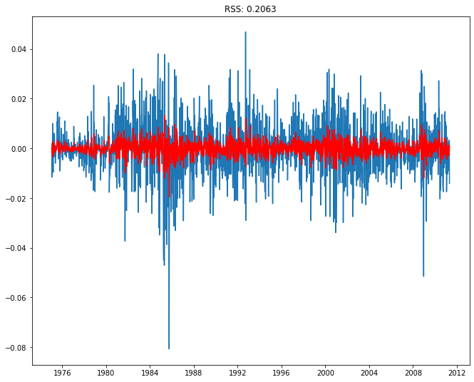

```python
plt.plot(Data_diff)
plt.plot(modelMovingA.fittedvalues, color='red')
plt.title('RSS: %.4f'% sum((modelMovingA.fittedvalues-Data_diff)**2))
```

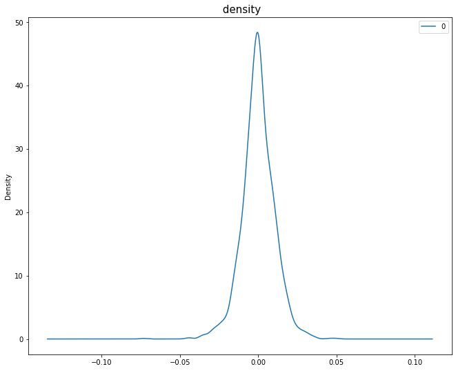

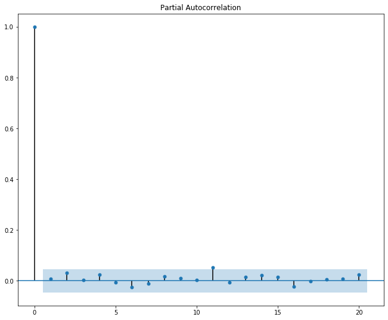

```python
residuals = pd.DataFrame(modelMovingA.resid)
residuals.plot(kind='kde')
plt.title(' density', fontsize=15)
plot_pacf(residuals, lags=20)
plt.show()
```

[output not shown]

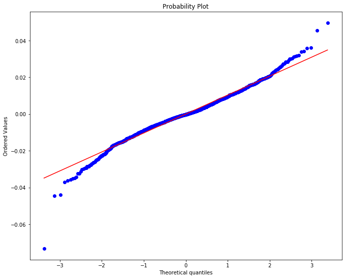

```python
from scipy import stats
plt.subplot(1,1,1)
stats.probplot(modelMovingA.resid, plot=plt)
```

### Forecasting

the forecast function will generate 3 results which are the forecasting results, the standard errors, and the prediction intervals

```python
fc, se, conf =modelMovingA.forecast(len(test),alpha=0.05)  # 95% conf
```

```python
observed= pd.DataFrame(test.values,index = test.index)
observed.columns = ['observed values']
observed
```

| Date | observed values |
| --- | --- |
| 2011-05-08 | 0.679825 |
| 2011-05-15 | 0.701100 |
| 2011-05-22 | 0.703600 |
| 2011-05-29 | 0.708700 |
| 2011-06-05 | 0.692000 |
| ... | ... |
| 2020-05-10 | 0.923100 |
| 2020-05-17 | 0.923020 |
| 2020-05-24 | 0.915340 |
| 2020-05-31 | 0.906200 |
| 2020-06-07 | 0.891225 |

475 rows × 1 columns

```python
predictedvalues= pd.DataFrame(fc,index = test.index)
predictedvalues.columns = ['values predicted']
predictedvalues
```

| Date | values predicted |
| --- | --- |
| 2011-05-08 | 0.676315 |
| 2011-05-15 | 0.676269 |
| 2011-05-22 | 0.676223 |
| 2011-05-29 | 0.676177 |
| 2011-06-05 | 0.676131 |
| ... | ... |
| 2020-05-10 | 0.654772 |
| 2020-05-17 | 0.654726 |
| 2020-05-24 | 0.654681 |
| 2020-05-31 | 0.654635 |
| 2020-06-07 | 0.654589 |

475 rows × 1 columns

```python
CI= pd.DataFrame(conf)
CI.columns = ['lower PI','upper PI']
CI.head()
```

|  | lower PI | upper PI |
| --- | --- | --- |
| 0 | 0.655864 | 0.696765 |
| 1 | 0.643245 | 0.709293 |
| 2 | 0.634236 | 0.718210 |
| 3 | 0.626828 | 0.725526 |
| 4 | 0.620385 | 0.731878 |

```python
verification_frame={'value':[],'verification':[]}
verification_frame=pd.DataFrame(verification_frame)
```

```python
for i in range (0,len(test)):
    if test[i]>= conf[i][0] and test[i]<= conf[i][1]:
        verification_frame.loc[i]=[ test[i],'True']
    else:
        verification_frame.loc[i]=[ test[i],'False']
```

```python
verification_frame
```

|  | value | verification |
| --- | --- | --- |
| 0 | 0.679825 | True |
| 1 | 0.701100 | True |
| 2 | 0.703600 | True |
| 3 | 0.708700 | True |
| 4 | 0.692000 | True |
| ... | ... | ... |
| 470 | 0.923100 | True |
| 471 | 0.923020 | True |
| 472 | 0.915340 | True |
| 473 | 0.906200 | True |
| 474 | 0.891225 | True |

475 rows × 2 columns

```python
seriesObj = verification_frame.apply(lambda x: True if 'True' in list(x) else False, axis=1)
numOfRows = len(seriesObj[seriesObj == True].index)
print('Observed Values that belongs to the Prediction Interval are  : ', numOfRows)
```

```
Observed Values that belongs to the Prediction Interval are  :  475
```

it means that all the test values are icluded in the prediction interval

```python
se= pd.DataFrame(se)
se.columns = ['standard error']
se.tail()
```

|  | standard error |
| --- | --- |
| 470 | 0.287005 |
| 471 | 0.287309 |
| 472 | 0.287614 |
| 473 | 0.287918 |
| 474 | 0.288222 |

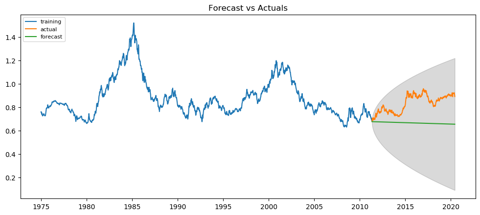

```python
fc_series = pd.Series(fc, index=test.index)
lower_series = pd.Series(conf[:, 0], index=test.index)
upper_series = pd.Series(conf[:, 1], index=test.index)
# Plot
plt.figure(figsize=(12,5), dpi=100)
plt.plot(train, label='training')
plt.plot(test, label='actual')
plt.plot(fc_series, label='forecast')
plt.fill_between(lower_series.index, lower_series, upper_series,
                 color='k', alpha=.15)
plt.title('Forecast vs Actuals')
plt.legend(loc='upper left', fontsize=8)
plt.show()
```

```python
def forecast_accuracy(forecast, actual):
    mape = np.mean(np.abs(forecast - actual)/np.abs(actual))  # MAPE
    me = np.mean(forecast - actual)             # ME
    mae = np.mean(np.abs(forecast - actual))    # MAE
    mpe = np.mean((forecast - actual)/actual)   # MPE
    rmse = np.mean((forecast - actual)**2)**.5  # RMSE

    return({'mape':mape, 'me':me, 'mae': mae,
            'mpe': mpe, 'rmse':rmse})

forecast_accuracy(fc, test.values)
```

```
{'mape': 0.1954626159614033,
 'me': -0.16885716189868014,
 'mae': 0.16885716189868014,
 'mpe': -0.1954626159614033,
 'rmse': 0.18608671327893309}
```

**Conclusion**

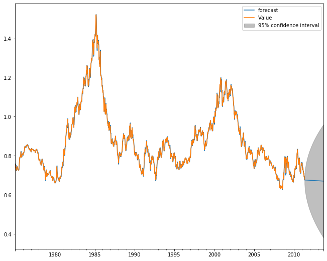

```python
### Out of sample forecasting

fig = modelMovingA.plot_predict(start=1, end=2020, dynamic=False)
```

## Other Forecasting methods

### smoothing Forecasting method

```python
size = int(len(times_series) - 474)
TRAIN, TEST = times_series[0:size], times_series[size:len(times_series)]
```

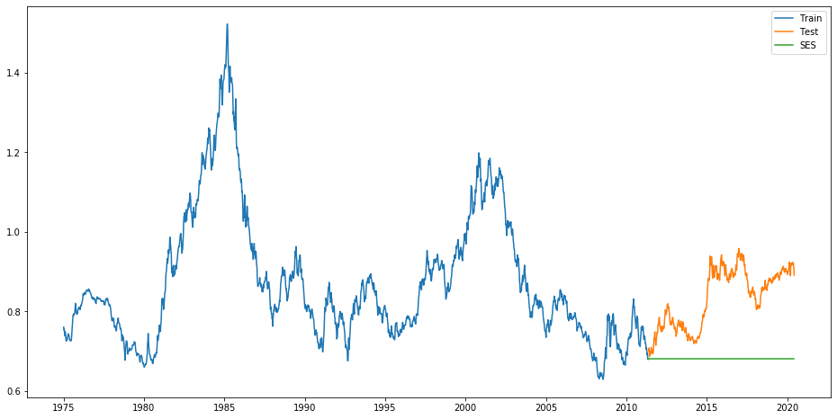

```python
from statsmodels.tsa.api import ExponentialSmoothing, SimpleExpSmoothing, Holt
y_hat_avg = TEST.copy()
fit2 = SimpleExpSmoothing(TRAIN).fit(smoothing_level=0.6,optimized=False)
y_hat_avg['SES']= fit2.forecast(len(TEST))

plt.figure(figsize=(16,8))
plt.plot(TRAIN, label='Train')
plt.plot(TEST, label='Test')
plt.plot(y_hat_avg['SES'], label='SES')
plt.legend(loc='best')
plt.show()
```

```python
from sklearn.metrics import mean_squared_error
from math import sqrt
rms = sqrt(mean_squared_error(TEST, y_hat_avg.SES))
print("Mean squared error of predictions is " ,rms)
```

```
Mean squared error of predictions is  0.16883081922630783
```

### Drawbacks of python

- *Through this project, I was able to learn more things about python.*
- *One of the major drawbacks of python is that it doesn't have all the packages and enough statistical tools to make our analysis. Also, there are a several python codes for time series analysis in the internet. However, some of these codes are wrong and they are distorting our results.*
- *I could not find the eacf function in the statsmodel.tsa package.*
- *Python graphs are more visually pleasent.*
- *Compared to python , R is much easier to work with. the major purpose of using R is for statistical analysis. That is why it is more trusted.*

**Overall, python does the job as R. However, we need to be more careful concerning the code used and the package used.**

### Packages verification

**The statsmodel package :** Most results have been verified with at least one other statistical package: R, Stata or SAS

**the scipy.stats package boxcox:**

This is the function used to ma ke the transformation

- y = (x**lmbda - 1) / lmbda, for lmbda > 0
- log(x), for lmbda = 0

For my data, I did not apply the log transformation I used the boxcox function just to generate the value of lambda I could not generate the confidence interval of lambda that is why I worked on R to check if 0 is included in the lambda interval. The results generated by R are the same as python.

### References

https://www.statsmodels.org/devel/about.html

https://www.statsmodels.org/stable/generated/statsmodels.tsa.arima_model.ARMAResults.forecast.html

https://docs.scipy.org/doc/scipy/reference/generated/scipy.stats.boxcox.html